# Plotting your first map in R

Connor French

4/16/2019

## Overview

This tutorial is aimed at folks used to performing GIS tasks on GUI platforms like ArcGIS or QGIS who want to explore R’s potential as a powerful, more reproducible, system for spatial visualization and analysis. It assumes no previous command-line experience. The tutorial is organized in the following sections:

**Installing and loading packages**

**Reading in data**

**Plotting the map**

All code can be executed by copying and pasting the below lines into an R console. You can download R for your system [here](https://cran.r-project.org/). However, if you have [RStudio](https://www.rstudio.com/products/rstudio/download/) and want to run the script while following along in the document, click [here](https://github.com/connor-french/maps-in-r-tutorial/archive/master.zip) to download the code for the tutorial and run the notebook. Just unzip the file and double-click the .Rmd file!

## Installing and loading packages

If you need to use a package that isn’t part of base R, you first need to install it. The install.packages() function is typically the safest and easiest way to install a package available in the CRAN repository. I put a hashmark in front of the function so it doesn’t query the repository and try to update the package every time you want to run this code. Remove the hashmark to install, then you can either remove the line of code, or add a hashmark back in front.

After the package is installed, it’s not quite ready to be used. To load a package into your session, use the library() function.

The main package we’re using in this tutorial is the raster package, a set of diverse tools for creating, reading, manipulating, and writing raster or vector data. This is a wonderful package that can do most, if not all, of the raster and vector manipulation tasks you regularly perform on a platform like ArcGIS or QGIS. We’re also using the rnaturalearth package to load in the shapefile we’ll need for our base map and spocc to obtain species occurrence localities that we want to visualize.

Install our packages.

```r
#You only need to do this once. The dependencies = TRUE argument tells the function to install any packages that are necessary to run the packages we are interested in.


#install.packages(c("raster", "rnaturalearth", "spocc"), dependencies = TRUE)
```

Load the packages into our environment.

```r
#Load the raster and rnaturalearth packages. The order you load packages matters, because some packages use similar function names and the last loaded package supercedes priority for function name.
library(raster)
library(rnaturalearth)
library(spocc)
```

## Reading in data

Before you can visualize your data, you need to read it in to your environment. For this tutorial, we will use two types of data- a shapefile for our base map and latitude/longitude coordinates for our points of interest. While you can easily read in data that you have on your computer, we’re grabbing some data available on the internet. Note- the arrow pointing to the left is assigning the output of the function on the right to the name on the left. Now, anytime you want to perform an operation on that output (for instance, plotting it!), you don’t have to run the function again.

Since I am partial to frogs, we’re going to plot the distribution of the Rufous Frog, a cute and chubby frog that is distributed across South America.

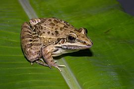

```r
#reading in a map of south america. Uses rnaturalearth package
sa_map <- ne_countries(continent = "south america")

#query a database to obtain our locality data. Uses spocc package.
frog_locs <- occ("Leptodactylus fuscus", from = "gbif", has_coords = TRUE)

#convert our query to a dataframe that we can plot. Uses spocc package.
frog_locs <- occ2df(frog_locs)

#tell R that the coordinates of this data set are the longitude and latitude variables. Uses sp package (which is loaded with raster package)
coordinates(frog_locs) <- ~longitude + latitude
```

## Plotting the map

This might be the easiest part of the process! There are many, many options to customize your map and many different packages that have their various pluses and minuses. However, a quick visualization of your data is obtainable with only two lines of code!

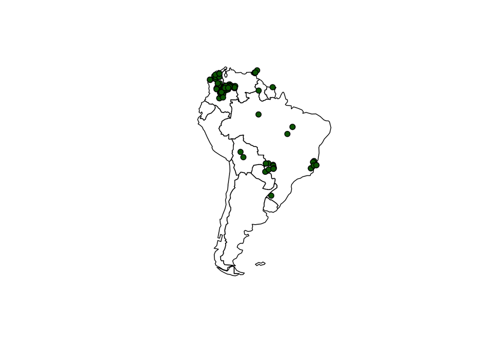

```r
#plot the basemap. Uses raster package.
plot(sa_map)

#plot the frog localities, making the border black and the center green. Uses raster package and base graphics.
points(frog_locs, col = "black", bg = "darkgreen", pch = 21)
```

### Some helpful resources

Here are a few helpful resources for getting started in R and making beautiful maps!

[Intro to R in RStudio](https://rstudio.cloud/learn/primers)

[Making beautiful maps in R](https://www.r-spatial.org/r/2018/10/25/ggplot2-sf.html)

[Geocomputation with R](https://geocompr.robinlovelace.net/)